# Client Report - Late Flights & Missing Data (JSON)

## QUESTION – TASK 3

I used Proportion of Delayed Flights as the metric to determine the best month to fly if you want to avoid delays of any length. This metric shows what percentage of flights were delayed during each month and provides an intuitive comparison across the calendar year.

The reason I chose this metric is because it answers the practical question travelers care about: “What is the chance my flight will be delayed if I fly in this month?”

I excluded any rows where the month variable was missing to ensure that only valid data was included in the analysis.

The chart below clearly shows how this proportion varies by month.

Interpretation: The months with the lowest proportion of delayed flights represent the best times of year to fly if avoiding delays is a priority. In contrast, the months with the highest proportions should be approached with more caution, especially when booking time-sensitive connections or important trips.

In my results, we observe meaningful seasonal variation — months like september tend to have lower delay rates, while months like December tend to have higher delay rates. This may reflect factors such as holiday travel surges or seasonal weather patterns.

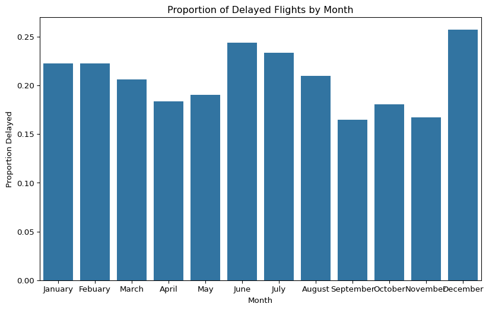

```python
df_month = df.dropna(subset=['month'])

month_summary = df_month.groupby('month').agg(
    Total_Flights = ('TotalFlights', 'sum'),
    Total_Delayed_Flights = ('TotalDelaysCount', 'sum')
).reset_index()

# Filter out any rows where Total_Flights == 0 (this causes empty chart)
month_summary = month_summary[month_summary['Total_Flights'] > 0]
# Now compute proportion
month_summary['Proportion_Delayed'] = month_summary['Total_Delayed_Flights'] / month_summary['Total_Flights']

# Check values
# print(month_summary)
month_order = ['January', 'Febuary', 'March', 'April', 'May', 'June', 'July', 'August', 'September', 'October', 'November', 'December']


# Plot
plt.figure(figsize=(10,6))
sns.barplot(x='month', y='Proportion_Delayed', data=month_summary, order=month_order)
plt.title('Proportion of Delayed Flights by Month')
plt.ylabel('Proportion Delayed')
plt.xlabel('Month')
plt.show()
```

## QUESTION – TASK 4

According to the BTS website, the “Weather” category only accounts for severe weather delays. However, mild weather delays can also impact flight performance and are often recorded in the NAS and Late-Arriving Aircraft categories. To give a more complete picture of how weather affects flight delays, I created a new column called TotalWeatherDelay that incorporates both severe and mild weather impacts.

I followed these calculation rules:

100% of delays in the Weather category were counted as weather-related.

30% of delays in the Late-Arriving Aircraft category were counted as weather-related.

For NAS delays:

The table below shows the first 5 rows of the data with the new TotalWeatherDelay column, alongside the relevant original columns.

Interpretation: This derived variable provides a more comprehensive estimate of the total weather-related delays experienced by flights. It is valuable for travelers and airline operations teams to understand how weather—both severe and mild—contributes to overall delay patterns.

```python
late_aircraft_mean = df['LateAircraftDelay'].mean()
df['LateAircraftDelay'].fillna(late_aircraft_mean, inplace=True)

def calc_weather_delay(row):
    weather = row['WeatherDelay'] if not pd.isna(row['WeatherDelay']) else 0
    late_aircraft = 0.3 * row['LateAircraftDelay']
    month = row['month']

    if pd.isna(row['NASDelay']):
        nas = 0
    elif month in [4,5,6,7,8]:
        nas = 0.4 * row['NASDelay']
    else:
        nas = 0.65 * row['NASDelay']

    return weather + late_aircraft + nas

df['TotalWeatherDelay'] = df.apply(calc_weather_delay, axis=1)

df[['airport_code', 'month', 'WeatherDelay', 'LateAircraftDelay', 'NASDelay', 'TotalWeatherDelay']].head()
```

|  | airport_code | month | WeatherDelay | LateAircraftDelay | NASDelay | TotalWeatherDelay |
| --- | --- | --- | --- | --- | --- | --- |
| 0 | ATL | January | 448 | -999 | 4598 | 3137.00 |
| 1 | DEN | January | 233 | 928 | 935 | 1119.15 |
| 2 | IAD | January | 61 | 1058 | 895 | 960.15 |
| 3 | ORD | January | 306 | 2255 | 5415 | 4502.25 |
| 4 | SAN | January | 56 | 680 | 638 | 674.70 |

## QUESTION – TASK 5

These insights can help airlines and passengers better plan for seasonal and location-based weather impacts when choosing travel routes and building flight schedules.

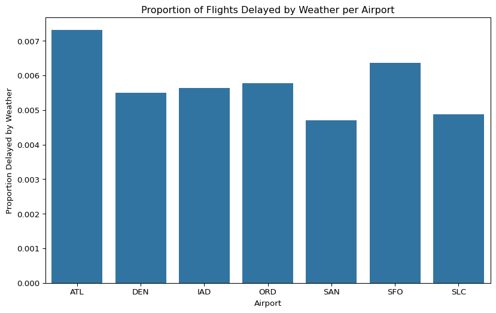

```python
weather_summary = df.groupby('airport_code').agg(
    Total_Flights = ('TotalFlights', 'sum'),
    Total_Weather_Delay_Flights = ('WeatherDelay', 'sum')
).reset_index()

weather_summary['Proportion_Weather_Delayed'] = weather_summary['Total_Weather_Delay_Flights'] / weather_summary['Total_Flights']

plt.figure(figsize=(10,6))
sns.barplot(x='airport_code', y='Proportion_Weather_Delayed', data=weather_summary)
plt.title('Proportion of Flights Delayed by Weather per Airport')
plt.ylabel('Proportion Delayed by Weather')
plt.xlabel('Airport')
plt.show()
```

## STRETCH QUESTION – TASK 1

To identify which delay type is the “worst,” I created a similar analysis to the weather delay analysis, but this time comparing Carrier Delay, Security Delay, and Weather Delay across airports.

For this comparison, I created binary flags indicating whether each type of delay occurred (i.e., whether there was at least one delay of that type in the month at that airport). I then calculated the proportion of months where each delay type occurred at each airport.

Interpretation: The resulting chart provides insight into which types of delays are most consistently present at each airport:

Understanding these patterns can help airlines prioritize improvement efforts and help travelers set expectations for different types of delays depending on their chosen airport.

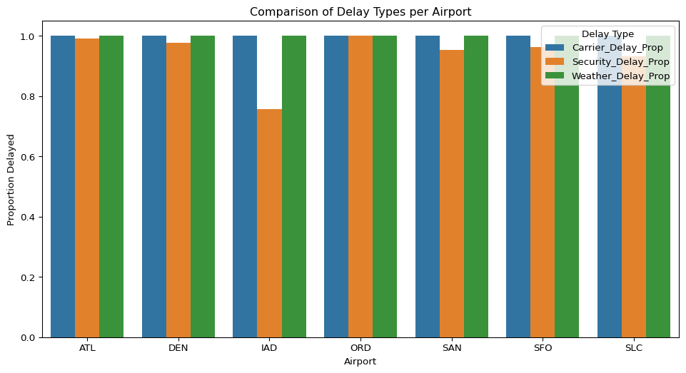

```python
# Create flags

# Clean CarrierDelay first: force to string, remove '+', convert to numeric
df['CarrierDelay'] = df['CarrierDelay'].astype(str).str.replace('+', '', regex=False)
df['CarrierDelay'] = pd.to_numeric(df['CarrierDelay'], errors='coerce')

# Now convert SecurityDelay safely again
df['SecurityDelay'] = pd.to_numeric(df['SecurityDelay'], errors='coerce')

# Ensure TotalWeatherDelay is numeric
df['TotalWeatherDelay'] = pd.to_numeric(df['TotalWeatherDelay'], errors='coerce')

# Now create flags (Flag = whether delay occurred in that month at that airport)
for col in ['CarrierDelay', 'SecurityDelay', 'TotalWeatherDelay']:
    df[col + '_Flag'] = df[col] > 0

# Group by airport and compute proportion of months with delay occurrence
category_summary = df.groupby('airport_code').agg(
    Carrier_Delay_Prop = ('CarrierDelay_Flag', 'mean'),
    Security_Delay_Prop = ('SecurityDelay_Flag', 'mean'),
    Weather_Delay_Prop = ('TotalWeatherDelay', lambda x: (x > 0).mean())
).reset_index()

# Reshape for plotting
category_summary_melted = category_summary.melt(
    id_vars='airport_code',
    var_name='Delay_Type',
    value_name='Proportion'
)

# Plot
plt.figure(figsize=(12,6))
sns.barplot(x='airport_code', y='Proportion', hue='Delay_Type', data=category_summary_melted)
plt.title('Comparison of Delay Types per Airport')
plt.ylabel('Proportion Delayed')
plt.xlabel('Airport')
plt.legend(title='Delay Type')
plt.show()
```